# Econ 10R Homework 2 Solutions

# Question 1

Use the New York City 2013 flights data (henceforth flights). Find the following flights:

1. The flight with the fastest speed
2. Flew to Houston (IAH or HOU)
3. Departed between midnight and 6am (red eyes)

```r
library(tidyverse)
library(nycflights13)
```

## Question 1a

To find the flight with the fastest speed, we need to calculate the speed of each flight, then arrange the data frame so that the flight with the highest speed is at the top:

```r
flights_speed <- mutate(flights, speed = distance / air_time * 60)
arrange(flights_speed, desc(flights_speed$speed))
```

```
## # A tibble: 336,776 × 20
##     year month   day dep_time sched_dep_time dep_delay arr_time sched_arr_time
##    <int> <int> <int>    <int>          <int>     <dbl>    <int>          <int>
##  1  2013     5    25     1709           1700         9     1923           1937
##  2  2013     7     2     1558           1513        45     1745           1719
##  3  2013     5    13     2040           2025        15     2225           2226
##  4  2013     3    23     1914           1910         4     2045           2043
##  5  2013     1    12     1559           1600        -1     1849           1917
##  6  2013    11    17      650            655        -5     1059           1150
##  7  2013     2    21     2355           2358        -3      412            438
##  8  2013    11    17      759            800        -1     1212           1255
##  9  2013    11    16     2003           1925        38       17             36
## 10  2013    11    16     2349           2359       -10      402            440
## # … with 336,766 more rows, and 12 more variables: arr_delay <dbl>,
## #   carrier <chr>, flight <int>, tailnum <chr>, origin <chr>, dest <chr>,
## #   air_time <dbl>, distance <dbl>, hour <dbl>, minute <dbl>, time_hour <dttm>,
## #   speed <dbl>
```

Alternatively we can use `filter` to select the flight based on the ranking of flight speed.

```r
filter(flights_speed, rank(desc(flights_speed$speed)) == 1)[, c("year", "month", "day", "dest", "carrier", "flight", "speed")]
```

```
## # A tibble: 1 × 7
##    year month   day dest  carrier flight speed
##   <int> <int> <int> <chr> <chr>    <int> <dbl>
## 1  2013     5    25 ATL   DL        1499  703.
```

Therefore the fastest flight is DL1499 on May 25th, with an average speed of 703mph. The average commercial flight speed is around 575mph, so this flight is rather fast, assuming that there are no errors in the data recording process.

## Question 1b

We can use `filter` to find all the flights between NYC and Houston:

```r
flights_houston <- filter(flights, dest == "IAH" | dest == "HOU")
flights_houston
```

```
## # A tibble: 9,313 × 19
##     year month   day dep_time sched_dep_time dep_delay arr_time sched_arr_time
##    <int> <int> <int>    <int>          <int>     <dbl>    <int>          <int>
##  1  2013     1     1      517            515         2      830            819
##  2  2013     1     1      533            529         4      850            830
##  3  2013     1     1      623            627        -4      933            932
##  4  2013     1     1      728            732        -4     1041           1038
##  5  2013     1     1      739            739         0     1104           1038
##  6  2013     1     1      908            908         0     1228           1219
##  7  2013     1     1     1028           1026         2     1350           1339
##  8  2013     1     1     1044           1045        -1     1352           1351
##  9  2013     1     1     1114            900       134     1447           1222
## 10  2013     1     1     1205           1200         5     1503           1505
## # … with 9,303 more rows, and 11 more variables: arr_delay <dbl>,
## #   carrier <chr>, flight <int>, tailnum <chr>, origin <chr>, dest <chr>,
## #   air_time <dbl>, distance <dbl>, hour <dbl>, minute <dbl>, time_hour <dttm>
```

## Question 1c

To find all the red eyes (midnight to 6am), we can apply `filter` again:

```r
flights_redeyes <- filter(flights, dep_time <= 600)
flights_redeyes
```

```
## # A tibble: 9,344 × 19
##     year month   day dep_time sched_dep_time dep_delay arr_time sched_arr_time
##    <int> <int> <int>    <int>          <int>     <dbl>    <int>          <int>
##  1  2013     1     1      517            515         2      830            819
##  2  2013     1     1      533            529         4      850            830
##  3  2013     1     1      542            540         2      923            850
##  4  2013     1     1      544            545        -1     1004           1022
##  5  2013     1     1      554            600        -6      812            837
##  6  2013     1     1      554            558        -4      740            728
##  7  2013     1     1      555            600        -5      913            854
##  8  2013     1     1      557            600        -3      709            723
##  9  2013     1     1      557            600        -3      838            846
## 10  2013     1     1      558            600        -2      753            745
## # … with 9,334 more rows, and 11 more variables: arr_delay <dbl>,
## #   carrier <chr>, flight <int>, tailnum <chr>, origin <chr>, dest <chr>,
## #   air_time <dbl>, distance <dbl>, hour <dbl>, minute <dbl>, time_hour <dttm>
```

# Question 2

Use flights, find the following destinations: a. All destinations that are served by at least two carriers b. The destination with the least flights c. The most popular destination in the summer (June, July, and August)

## Question 2a

To find all the destinations served by at least two carriers, we can do the following:

```r
flights_two <- mutate(group_by(flights, dest), n_carriers = n_distinct(carrier))
flights_two <- filter(flights_two, n_carriers > 1)
unique(flights_two$dest)
```

```
##  [1] "IAH" "MIA" "BQN" "ATL" "ORD" "FLL" "IAD" "MCO" "PBI" "TPA" "LAX" "SFO"
## [13] "DFW" "BOS" "LAS" "MSP" "DTW" "RSW" "SJU" "PHX" "BWI" "CLT" "BUF" "DEN"
## [25] "MSY" "SLC" "XNA" "MKE" "SEA" "ROC" "SYR" "SRQ" "RDU" "CMH" "JAX" "CHS"
## [37] "MEM" "PIT" "SAN" "DCA" "CLE" "STL" "JAC" "HNL" "BNA" "AUS" "BTV" "PHL"
## [49] "STT" "EGE" "AVL" "PWM" "IND" "HOU" "DAY" "BDL" "MHT" "MSN" "GSO" "CVG"
## [61] "RIC" "GSP" "GRR" "MCI" "ORF" "SAT" "SDF" "PDX" "SJC" "OMA" "TYS" "DSM"
## [73] "CAE" "BGR" "MVY" "TVC"
```

## Question 2b

To find the destination with the least flights, we can do the following:

```r
flights_least <- mutate(group_by(flights, dest), count = n())
flights_least <- arrange(flights_least, count)
select(flights_least, year, month, day, dest)
```

```
## # A tibble: 336,776 × 4
## # Groups:   dest [105]
##     year month   day dest
##    <int> <int> <int> <chr>
##  1  2013    11    24 LEX
##  2  2013     7    27 LGA
##  3  2013     7     6 ANC
##  4  2013     7    13 ANC
##  5  2013     7    20 ANC
##  6  2013     7    27 ANC
##  7  2013     8     3 ANC
##  8  2013     8    10 ANC
##  9  2013     8    17 ANC
## 10  2013     8    24 ANC
## # … with 336,766 more rows
```

We set the unit of analysis to `dest`, the counted each destination’s number of appearance in the data. We can then arranged the rows by the value of `count` in ascending order.

So we found two airports that got served the least. If you look carefully at the dataset, you will notice that `LGA` is actually LaGuardia, which is in NYC. The flight was between Newark and LaGuardia, so it is likely a diversion. Therefore `LEX` is truly the least served airport.

## Question 2c

To get the most popular destination in the summer, we can apply functions similar to the previous questions:

```r
flights_summer <- filter(flights,
                         month == 6 | month == 7 | month == 8)
flights_summer <- mutate(group_by(flights_summer, dest), count = n())
flights_summer <- arrange(flights_summer, desc(count))
select(flights_summer, year, month, day, dest)
```

```
## # A tibble: 86,995 × 4
## # Groups:   dest [96]
##     year month   day dest
##    <int> <int> <int> <chr>
##  1  2013     6     1 ORD
##  2  2013     6     1 ORD
##  3  2013     6     1 ORD
##  4  2013     6     1 ORD
##  5  2013     6     1 ORD
##  6  2013     6     1 ORD
##  7  2013     6     1 ORD
##  8  2013     6     1 ORD
##  9  2013     6     1 ORD
## 10  2013     6     1 ORD
## # … with 86,985 more rows
```

We kept flights in the summer only, counted the number of appearance for each destination, and then ranked them. It is clear that `ORD` (Chicago) is the most popular destination over the summer, with 4724 flights served.

Alternatively, you can collapse the data frame by taking the average of `count` for each `dest` and then apply `rank` to get the top 1.

# Question 3

Use flights, generate a variable that measures the time gained in air (departure delay minus arrival delay). Calculate the correlation between time gained in air and the distance to destination. Plot them on a graph. You can plot the graph in any way you like, but you must include the correct labels for each axis and a title.

To do so, let’s first generate the time gained variable:

```r
flights_gain <- mutate(flights, gain = dep_delay - arr_delay)
flights_gain <- na.omit(flights_gain)
```

Then we can use `cor` to get the correlation coefficient between `gain` and `distance`:

```r
cor(flights_gain$gain, flights_gain$distance)
```

```
## [1] 0.1048957
```

So we have a positive but relatively weak relationship between the two. Let us plot it in a graph:

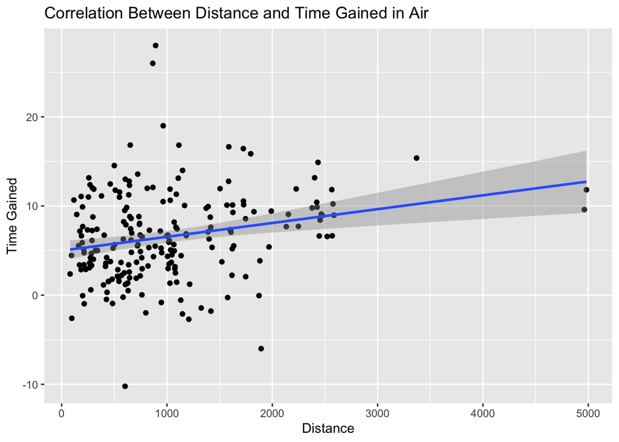

```r
flights_gain <- summarise(group_by(flights_gain, distance),
                          gain_mean = mean(gain))
ggplot(data = flights_gain, aes(x = distance, y = gain_mean)) +
  geom_point() +
  geom_smooth(method = lm) +
  labs(title = "Correlation Between Distance and Time Gained in Air",
       x = "Distance", y = "Time Gained")
```

In order to make the graph more presentable, I took the average of the gain conditional on the same distance. It is not necessary to do so, but it makes the graph much clearer.

# Question 4

Use the function `lag`, explore how the delay of a flight is related to the delay of the immediately preceding flight. Plot them on a graph.

We first need to generate the lag variables. Let us arrange the data by airport-date-departure time:

```r
flights_delay <- arrange(flights, origin, month, day, dep_time)
```

Now we can generate a new variable, the lagged version of departure delay:

```r
flights_delay <- na.omit(mutate(flights_delay, dep_delay_lag = lag(dep_delay)))
```

We can first check the correlation between delays and lagged delays:

```r
cor(flights_delay$dep_delay, flights_delay$dep_delay_lag)
```

```
## [1] 0.3502349
```

Which is reasonably high. Let’s plot this:

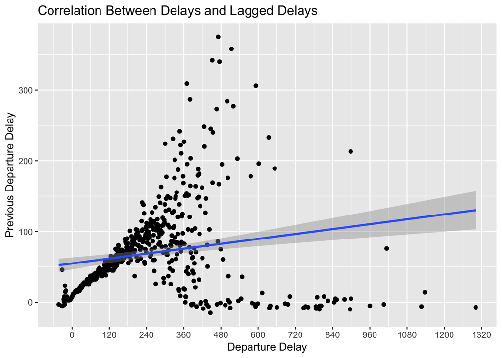

```r
flights_delay <- summarise(group_by(flights_delay, dep_delay_lag),
          dep_delay_mean = mean(dep_delay))
ggplot(data = flights_delay, aes(x = dep_delay_lag, y = dep_delay_mean)) +
  geom_point() +
  geom_smooth(method = lm) +
  scale_x_continuous(breaks = seq(0, 1500, by = 120)) +
  labs(title = "Correlation Between Delays and Lagged Delays",
       x = "Departure Delay", y = "Previous Departure Delay")
```